# (Fordgobike Dataset)

## Preliminary Wrangling

> I have chosen the fordgobike dataset which covers trips over Februrary starting from and ending to different locations. Each row represents some info which belongs to a participant like his birth year, starting location, its user type, time taken through the trip, etc. Then, I will be running some wrangling steps to help me investigate the dataset and come up with valuable insights.

```python
# import all packages and set plots to be embedded inline
import numpy as np
import pandas as pd
import matplotlib.pyplot as plt
import seaborn as sb

%matplotlib inline
```

```python
ford= pd.read_csv('fordgobike.csv')
ford.head(1)
```

|  | duration_sec | start_time | end_time | start_station_id | start_station_name | start_station_latitude | start_station_longitude | end_station_id | end_station_name | end_station_latitude | end_station_longitude | bike_id | user_type | member_birth_year | member_gender | bike_share_for_all_trip |
| --- | --- | --- | --- | --- | --- | --- | --- | --- | --- | --- | --- | --- | --- | --- | --- | --- |
| 0 | 52185 | 2019-02-28 17:32:10.1450 | 2019-03-01 08:01:55.9750 | 21.0 | Montgomery St BART Station (Market St at 2nd St) | 37.789625 | -122.400811 | 13.0 | Commercial St at Montgomery St | 37.794231 | -122.402923 | 4902 | Customer | 1984.0 | Male | No |

```python
#Dataset Structure
ford.shape
```

```
(183412, 16)
```

```python
#Checking if there are null values
ford.isnull().sum()
```

```
duration_sec                  0
start_time                    0
end_time                      0
start_station_id            197
start_station_name          197
start_station_latitude        0
start_station_longitude       0
end_station_id              197
end_station_name            197
end_station_latitude          0
end_station_longitude         0
bike_id                       0
user_type                     0
member_birth_year          8265
member_gender              8265
bike_share_for_all_trip       0
dtype: int64
```

```python
#Checking if there are duplicates
ford.duplicated().sum()
```

```
0
```

```python
#Checking the types of each column included in the dataset
ford.info()
```

```
<class 'pandas.core.frame.DataFrame'>
RangeIndex: 183412 entries, 0 to 183411
Data columns (total 16 columns):
 #   Column                   Non-Null Count   Dtype
---  ------                   --------------   -----
 0   duration_sec             183412 non-null  int64
 1   start_time               183412 non-null  object
 2   end_time                 183412 non-null  object
 3   start_station_id         183215 non-null  float64
 4   start_station_name       183215 non-null  object
 5   start_station_latitude   183412 non-null  float64
 6   start_station_longitude  183412 non-null  float64
 7   end_station_id           183215 non-null  float64
 8   end_station_name         183215 non-null  object
 9   end_station_latitude     183412 non-null  float64
 10  end_station_longitude    183412 non-null  float64
 11  bike_id                  183412 non-null  int64
 12  user_type                183412 non-null  object
 13  member_birth_year        175147 non-null  float64
 14  member_gender            175147 non-null  object
 15  bike_share_for_all_trip  183412 non-null  object
dtypes: float64(7), int64(2), object(7)
memory usage: 22.4+ MB
```

```python
#Dropping all the null values for the accuracuy of our data
ford.dropna(inplace = True)
```

```python
#Some summaries about the columns of interest
print(ford['duration_sec'].describe())
print(ford['member_gender'].value_counts())
print(ford['user_type'].value_counts())
print(ford['bike_share_for_all_trip'].value_counts())
```

```
count    174952.000000
mean        704.002744
std        1642.204905
min          61.000000
25%         323.000000
50%         510.000000
75%         789.000000
max       84548.000000
Name: duration_sec, dtype: float64
Male      130500
Female     40805
Other       3647
Name: member_gender, dtype: int64
Subscriber    158386
Customer       16566
Name: user_type, dtype: int64
No     157606
Yes     17346
Name: bike_share_for_all_trip, dtype: int64
```

```python
#Top 2o birth years represented through the dataset and each has considerable amount
ford['member_birth_year'].value_counts().iloc[:20]
```

```
1988.0    10214
1993.0     9323
1989.0     8967
1990.0     8640
1991.0     8484
1992.0     8245
1987.0     8010
1986.0     7953
1994.0     7654
1995.0     7420
1985.0     7023
1984.0     6557
1983.0     5953
1980.0     5011
1982.0     4987
1996.0     4637
1981.0     4344
1979.0     3756
1997.0     3476
1998.0     3208
Name: member_birth_year, dtype: int64
```

```python
#No of starting stations in the dataset and its top ten
print(ford['start_station_name'].nunique())
print(ford['start_station_name'].value_counts().iloc[:10])
```

```
329
Market St at 10th St                                         3649
San Francisco Caltrain Station 2  (Townsend St at 4th St)    3408
Berry St at 4th St                                           2952
Montgomery St BART Station (Market St at 2nd St)             2711
Powell St BART Station (Market St at 4th St)                 2620
San Francisco Caltrain (Townsend St at 4th St)               2577
San Francisco Ferry Building (Harry Bridges Plaza)           2541
Howard St at Beale St                                        2216
Steuart St at Market St                                      2191
Powell St BART Station (Market St at 5th St)                 2144
Name: start_station_name, dtype: int64
```

```python
#No of ending stations in the dataset and its top ten
print(ford['end_station_name'].nunique())
print(ford['end_station_name'].value_counts().iloc[:10])
```

```
329
San Francisco Caltrain Station 2  (Townsend St at 4th St)    4624
Market St at 10th St                                         3709
Montgomery St BART Station (Market St at 2nd St)             3461
San Francisco Ferry Building (Harry Bridges Plaza)           3151
San Francisco Caltrain (Townsend St at 4th St)               2870
Powell St BART Station (Market St at 4th St)                 2854
Berry St at 4th St                                           2782
The Embarcadero at Sansome St                                2341
Steuart St at Market St                                      2264
Powell St BART Station (Market St at 5th St)                 2153
Name: end_station_name, dtype: int64
```

```python
#Transforming start and end time columns to datetime type
ford['start_time'] = pd.to_datetime(ford['start_time'])
ford['end_time'] = pd.to_datetime(ford['end_time'])
```

```python
#Transforming columns of discrete values from float to int type
ford['start_station_id'] = ford['start_station_id'].astype(int)
ford['end_station_id'] = ford['end_station_id'].astype(int)
ford['member_birth_year'] = ford['member_birth_year'].astype(int)
```

```python
#Rechecking all the steps run above to ensure that they are already done
ford.info()
```

```
<class 'pandas.core.frame.DataFrame'>
Int64Index: 174952 entries, 0 to 183411
Data columns (total 16 columns):
 #   Column                   Non-Null Count   Dtype
---  ------                   --------------   -----
 0   duration_sec             174952 non-null  int64
 1   start_time               174952 non-null  datetime64[ns]
 2   end_time                 174952 non-null  datetime64[ns]
 3   start_station_id         174952 non-null  int32
 4   start_station_name       174952 non-null  object
 5   start_station_latitude   174952 non-null  float64
 6   start_station_longitude  174952 non-null  float64
 7   end_station_id           174952 non-null  int32
 8   end_station_name         174952 non-null  object
 9   end_station_latitude     174952 non-null  float64
 10  end_station_longitude    174952 non-null  float64
 11  bike_id                  174952 non-null  int64
 12  user_type                174952 non-null  object
 13  member_birth_year        174952 non-null  int32
 14  member_gender            174952 non-null  object
 15  bike_share_for_all_trip  174952 non-null  object
dtypes: datetime64[ns](2), float64(4), int32(3), int64(2), object(5)
memory usage: 20.7+ MB
```

```python
#Extracting age from birth year for each member in a new column to use in our charts as a reference to the year where they took the trips
ford['age'] = (2019 - ford['member_birth_year']).astype(int)
ford['age'].head(5)
```

```
0    35
2    47
3    30
4    45
5    60
Name: age, dtype: int32
```

```python
#Extracting days of week and days of month from the datetime columns
ford['dayofmonth'] = ford['start_time'].dt.day
ford['dayofweek'] = ford['start_time'].dt.weekday
ford['dayofweek'].replace({0, 1, 2, 3, 4, 5, 6},{'Monday', 'Tuesday', 'Wednesday', 'Thursday', 'Friday', 'Saturday', 'Sunday'}, inplace=True)
print(ford['dayofmonth'].unique())
print(ford['dayofweek'].unique())
```

```
[28 27 26 25 24 23 22 21 20 19 18 17 16 15 14 13 12 11 10  9  8  7  6  5
  4  3  2  1]
['Tuesday' 'Friday' 'Saturday' 'Monday' 'Thursday' 'Sunday' 'Wednesday']
```

```python
#Dividing the day into 3 times "morning, afternoon and night"
ford['starting_hour'] = ford['start_time'].apply(lambda time: time.hour)
ford['daysequence'] = 'Morning'
ford['daysequence'][(ford['starting_hour'] >= 12) & (ford['starting_hour'] <= 17)] = 'Afternoon'
ford['daysequence'][(ford['starting_hour'] >= 18) & (ford['starting_hour'] <= 23)] = 'Night'
```

[output not shown]

```python
#Checking the no of trips done per hour and per period of the day
print(ford['starting_hour'].value_counts())
print(ford['daysequence'].value_counts())
```

```
17    20904
8     20227
18    16118
9     15204
16    13473
7     10231
19     9424
15     8646
12     8220
13     8098
10     7970
14     7677
11     7461
20     6211
21     4400
6      3293
22     2793
23     1572
0       893
5       866
1       525
2       355
4       227
3       164
Name: starting_hour, dtype: int64
Morning      67416
Afternoon    67018
Night        40518
Name: daysequence, dtype: int64
```

```python
#Using the lat and long columns to get the distance based on the mentioned link and the other one to ensure that it matches our area of the dataset

#https://gist.github.com/rochacbruno/2883505
#https://www.latlong.net/Show-Latitude-Longitude.html
import math
def calculateDistance(dist):
    lat1 = dist['start_station_latitude']
    lon1 = dist['start_station_longitude']
    lat2 = dist['end_station_latitude']
    lon2 = dist['end_station_longitude']
    radius = 6371 # km radius of earth
    dlat = math.radians(lat2-lat1)
    dlon = math.radians(lon2-lon1)
    a = math.sin(dlat/2) * math.sin(dlat/2) + math.cos(math.radians(lat1)) \
        * math.cos(math.radians(lat2)) * math.sin(dlon/2) * math.sin(dlon/2)
    c = 2 * math.atan2(math.sqrt(a), math.sqrt(1-a))
    d = radius * c
    return d

ford['distance'] = ford.apply(lambda dist: calculateDistance(dist), axis=1)
```

```python
ford.info()
```

```
<class 'pandas.core.frame.DataFrame'>
Int64Index: 174952 entries, 0 to 183411
Data columns (total 22 columns):
 #   Column                   Non-Null Count   Dtype
---  ------                   --------------   -----
 0   duration_sec             174952 non-null  int64
 1   start_time               174952 non-null  datetime64[ns]
 2   end_time                 174952 non-null  datetime64[ns]
 3   start_station_id         174952 non-null  int32
 4   start_station_name       174952 non-null  object
 5   start_station_latitude   174952 non-null  float64
 6   start_station_longitude  174952 non-null  float64
 7   end_station_id           174952 non-null  int32
 8   end_station_name         174952 non-null  object
 9   end_station_latitude     174952 non-null  float64
 10  end_station_longitude    174952 non-null  float64
 11  bike_id                  174952 non-null  int64
 12  user_type                174952 non-null  object
 13  member_birth_year        174952 non-null  int32
 14  member_gender            174952 non-null  object
 15  bike_share_for_all_trip  174952 non-null  object
 16  age                      174952 non-null  int32
 17  dayofmonth               174952 non-null  int64
 18  dayofweek                174952 non-null  object
 19  starting_hour            174952 non-null  int64
 20  daysequence              174952 non-null  object
 21  distance                 174952 non-null  float64
dtypes: datetime64[ns](2), float64(5), int32(4), int64(4), object(7)
memory usage: 28.0+ MB
```

```python
# convert day sequence and weekday into ordered categorical types
ordinal_var_dict = {'daysequence': ['Morning', 'Afternoon', 'Night'],
                    'dayofweek': ['Monday', 'Tuesday', 'Wednesday', 'Thursday', 'Friday', 'Saturday', 'Sunday']}

for var in ordinal_var_dict:
    ordered_var = pd.api.types.CategoricalDtype(ordered = True, categories = ordinal_var_dict[var])
    ford[var] = ford[var].astype(ordered_var)
```

### What is the structure of your dataset?

The dataset consists of 183412 rows and 16 columns, some of them are categorical data "nominal and ordinal" and others are quantitative data "continuous and dicrete". There are some columns having null values and others having non-meaningless value. In addition, some other columns have been deduced from the existing data to help me further investigate and find relations among numerous variables. Also, dataset only covers one or two months and this doesn't give me the chance to look at the distribution over months and it will be replaced by looking at the distribution over the included month and day of week.

### What is/are the main feature(s) of interest in your dataset?

There are main features of interest like when and where most of the trips had started, is the young age directly proportional to the longer trips besides coordinates columns which could give us insights to distances taken across the trips.

### What features in the dataset do you think will help support your investigation into your feature(s) of interest?

Some of them I deduced and others are already existed like duration, age, day sequence, day of week and others with minimal impact would help me dig deeper for an in-depth analysis for the features of interest.

## Univariate Exploration

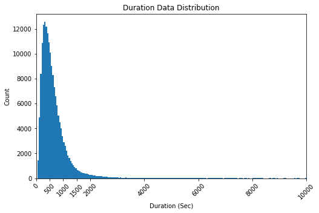

```python
binsize = 50
bins= np.arange(0, ford['duration_sec'].max()+ binsize, binsize)
plt.figure(figsize=(8,5))
plt.hist(data=ford, x='duration_sec', bins=bins)
plt.xlim(0, 10000)
plt.xticks([0, 500, 1000, 1500, 2000,  4000,  6000,  8000, 10000], rotation= 45);
plt.xlabel('Duration (Sec)')
plt.ylabel('Count')
plt.title('Duration Data Distribution');
```

#### Plotting the data of duration to figrure out its distribution and as shown there is a right skewness. In addition, the main data are focused to 2000 seconds and there is a long tail indicating high duration values. So, we will run it through a log scale for better visualization.

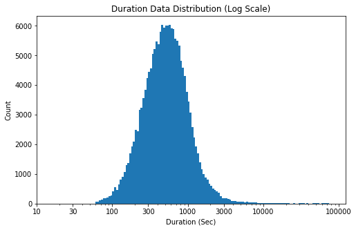

```python
binsize = 0.025
bins= 10 ** np.arange(1.6, np.log10(ford['duration_sec'].max()+ binsize), binsize)
plt.figure(figsize=(8,5))
plt.hist(data=ford, x='duration_sec', bins=bins)
plt.xscale('log')
plt.xticks([10, 30, 100, 300, 1000, 3000, 10000, 100000], [10, 30, 100, 300, 1000, 3000, 10000, 100000])
plt.xlabel('Duration (Sec)')
plt.ylabel('Count')
plt.title('Duration Data Distribution (Log Scale)');
```

#### After plotting the data in log scale, it turns out that the peak of duration is concentrated over a range from 300 to 1000 seconds which are 5 to 17 minutes. In addition, it's highly confirmed that values which extends over than 10000 seconds. So, we shall further investigate if they are outliers or real data.

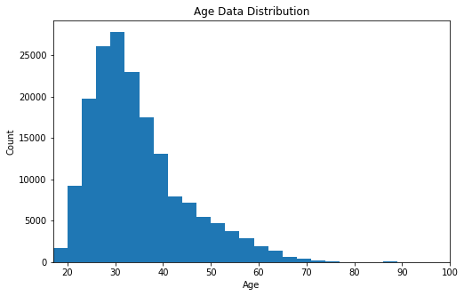

```python
binsize = 3
bins= np.arange(17, ford['age'].max()+ binsize, binsize)
plt.figure(figsize=(8,5))
plt.hist(data=ford, x='age', bins=bins)
plt.xlim(17, 100)
plt.xlabel('Age')
plt.ylabel('Count')
plt.title('Age Data Distribution');
```

#### Moving to another variable of interest which is the age and it is obvoius that right skewness and the members whose age more than 70 and 80. Despite the physical abilities and are they capable of doing so, we shall investigate and to decide to drop it or not.

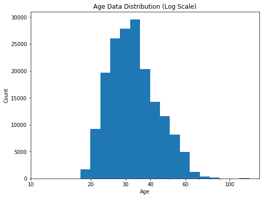

```python
binsize = 0.05
bins= 10 ** np.arange(1.1, np.log10(ford['age'].max()+ binsize), binsize)
plt.figure(figsize=(8,6))
plt.hist(data=ford, x='age', bins=bins)
plt.xscale('log')
plt.xticks([10, 20, 30, 40, 60, 100], [10, 20, 30, 40, 60, 100])
plt.xlabel('Age')
plt.ylabel('Count')
plt.title('Age Data Distribution (Log Scale)');
```

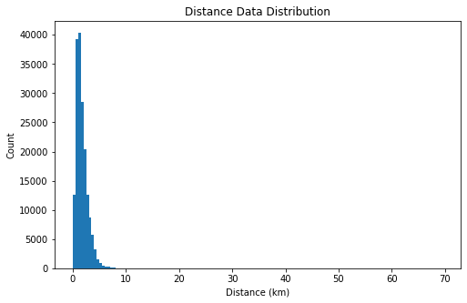

```python
binsize = 0.5
bins= np.arange(0, ford['distance'].max()+ binsize, binsize)
plt.figure(figsize=(8,5))
plt.hist(data=ford, x='distance', bins=bins);
plt.xlabel('Distance (km)')
plt.ylabel('Count')
plt.title('Distance Data Distribution');
```

#### While figuring out our variables, here it comes to the third one which is deduced using the coordinates columns to define how much distance had been taken per each trip and it turns out that majority of trips is less than 10 km.

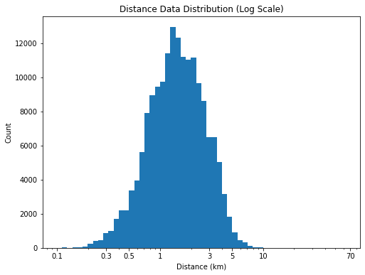

```python
binsize = 0.05
bins= 10 ** np.arange(-1, np.log10(ford['distance'].max()+ binsize), binsize)
plt.figure(figsize=(8,6))
plt.hist(data=ford, x='distance', bins=bins)
plt.xscale('log')
plt.xticks([0.1, 0.3, 0.5, 1, 3, 5, 10, 70], [ 0.1, 0.3, 0.5, 1, 3, 5, 10, 70])
plt.xlabel('Distance (km)')
plt.ylabel('Count')
plt.title('Distance Data Distribution (Log Scale)');
```

#### For better visualization to the data, we transformed the distance to log scale to figure out that the peak of distance is between 1 and 3 kms. In addition, there are some outliers which aren't shown clearly like 69 km for instance that we shall further check to ensure its credibility. Over and above, we will use the distance columns in many charts to figure out its consistency or correlation with other columns of interest.

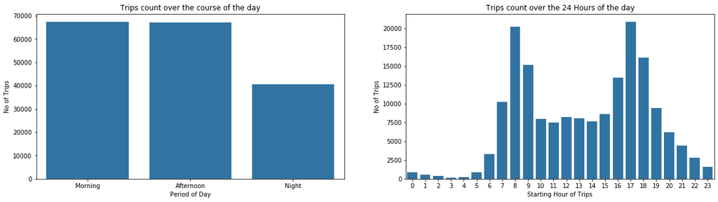

```python
plt.figure(figsize=[20,5])

plt.subplot(1,2,1)
base_color= sb.color_palette()[0]
sb.countplot(data= ford, x='daysequence', color=base_color)
plt.xlabel('Period of Day')
plt.ylabel('No of Trips')
plt.title('Trips count over the course of the day')

plt.subplot(1,2,2)
base_color= sb.color_palette()[0]
sb.countplot(data= ford, x='starting_hour', color= base_color)
plt.xlabel('Starting Hour of Trips')
plt.ylabel('No of Trips')
plt.title('Trips count over the 24 Hours of the day');
```

#### Another point to consider that morning has slightly higher number of trips than afternoon, but it covers more hours compared to the afternoon period.

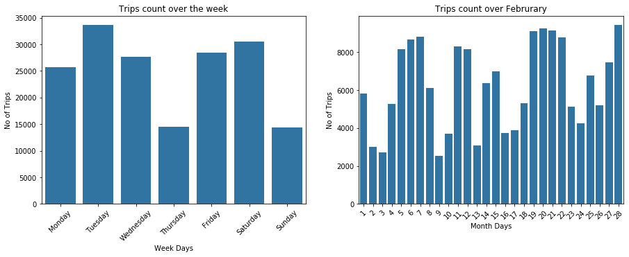

```python
plt.figure(figsize=[15,5])

plt.subplot(1,2,1)
base_color= sb.color_palette()[0]
sb.countplot(data=ford, x='dayofweek', color=base_color);
plt.xticks(rotation=45)
plt.xlabel('Week Days')
plt.ylabel('No of Trips')
plt.title('Trips count over the week')

plt.subplot(1,2,2)
base_color= sb.color_palette()[0]
sb.countplot(data=ford, x='dayofmonth',  color=base_color)
plt.xticks(rotation=45)
plt.xlabel('Month Days')
plt.ylabel('No of Trips')
plt.title('Trips count over Februrary');
```

[figure not shown]

```python
#Tops ten start and end stations
plt.figure(figsize=[5,10])

plt.subplot(2,1,1)
base_color= sb.color_palette()[0]
ford['start_station_name'].value_counts().iloc[:10].plot(kind='barh')
plt.xlabel('Count')
plt.ylabel('Top Ten Starting Stations')
plt.title('Number of Trips Over the top ten starting stations')

plt.subplot(2,1,2)
base_color= sb.color_palette()[0]
ford['end_station_name'].value_counts().iloc[:10].plot(kind='barh')
plt.xlabel('Count')
plt.ylabel('Top Ten Ending Stations')
plt.title('Number of Trips Over the top ten ending stations');
```

#### Running the analysis over the start and end stations to figure out some points: the number of trips started from the top ten stations and the number of trips ended at the top ten stations. It turned out that some of the top starting stations are in the top of the ending stations as well.

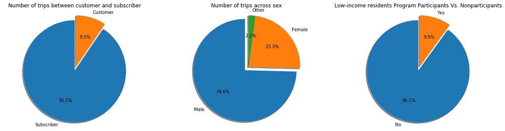

```python
plt.figure(figsize=[20,5])

plt.subplot(1,3,1)
labels = 'Subscriber', 'Customer'
explode = (0.1, 0)
plt.pie(ford['user_type'].value_counts(), explode=explode, labels=labels, autopct='%1.1f%%', shadow=True, startangle=90)
plt.axis('equal')
plt.title('Number of trips between customer and subscriber')


plt.subplot(1,3,2)
labels = 'Male', 'Female','Other'
explode = (0.1, 0, 0)
plt.pie(ford['member_gender'].value_counts(), explode=explode, labels=labels, autopct='%1.1f%%', shadow=True, startangle=90)
plt.axis('equal')
plt.title('Number of trips across sex')


plt.subplot(1,3,3)
labels = 'No', 'Yes'
explode = (0.1, 0)
plt.pie(ford['bike_share_for_all_trip'].value_counts(), explode=explode, labels=labels, autopct='%1.1f%%', shadow=True, startangle=90)
plt.axis('equal')
plt.title('Low-income residents Program Participants Vs. Nonparticipants')


plt.show()
```

#### Here are two distributions of the trips' participants where over 90% are subscribers and around 75% of both of them are males. A customer is someone who holds a single-ride or day pass while a subscriber carries a monthly or annual pass. In addition, we shall further investigate the percentage of the "other" category and what it does represent. We also need to figure out thoroughly Gender vs. User Type. Furthermore, exploring another variable "bike share for all trip" which tracks members who are enrolled in the bike share for all program for low-income residents.

#### Although the higher number of participants are subsvribers, they aren't enrolled in the bike share program for low-income residents.

### Some investigations to do based on our exploration.

#### 1-Ages > 70 & 100 years.

#### 2-Very long duration.

#### 3-Very small and long Distance.

```python
#Checking members of ages older than 70 then 100 years old
ford.query('age > 100')
```

|  | duration_sec | start_time | end_time | start_station_id | start_station_name | start_station_latitude | start_station_longitude | end_station_id | end_station_name | end_station_latitude | ... | user_type | member_birth_year | member_gender | bike_share_for_all_trip | age | dayofmonth | dayofweek | starting_hour | daysequence | distance |
| --- | --- | --- | --- | --- | --- | --- | --- | --- | --- | --- | --- | --- | --- | --- | --- | --- | --- | --- | --- | --- | --- |
| 1285 | 148 | 2019-02-28 19:29:17.627 | 2019-02-28 19:31:45.967 | 158 | Shattuck Ave at Telegraph Ave | 37.833279 | -122.263490 | 173 | Shattuck Ave at 55th St | 37.840364 | ... | Subscriber | 1900 | Male | Yes | 119 | 28 | Tuesday | 19 | Night | 0.792753 |
| 10827 | 1315 | 2019-02-27 19:21:34.436 | 2019-02-27 19:43:30.008 | 343 | Bryant St at 2nd St | 37.783172 | -122.393572 | 375 | Grove St at Masonic Ave | 37.774836 | ... | Subscriber | 1900 | Male | No | 119 | 27 | Friday | 19 | Night | 4.747020 |
| 16087 | 1131 | 2019-02-27 08:37:36.864 | 2019-02-27 08:56:28.022 | 375 | Grove St at Masonic Ave | 37.774836 | -122.446546 | 36 | Folsom St at 3rd St | 37.783830 | ... | Subscriber | 1900 | Male | No | 119 | 27 | Friday | 8 | Morning | 4.307705 |
| 19375 | 641 | 2019-02-26 17:03:19.855 | 2019-02-26 17:14:01.619 | 9 | Broadway at Battery St | 37.798572 | -122.400869 | 30 | San Francisco Caltrain (Townsend St at 4th St) | 37.776598 | ... | Customer | 1900 | Male | No | 119 | 26 | Saturday | 17 | Afternoon | 2.492247 |
| 21424 | 1424 | 2019-02-26 08:58:02.904 | 2019-02-26 09:21:47.749 | 375 | Grove St at Masonic Ave | 37.774836 | -122.446546 | 343 | Bryant St at 2nd St | 37.783172 | ... | Subscriber | 1900 | Male | No | 119 | 26 | Saturday | 8 | Morning | 4.747020 |
| ... | ... | ... | ... | ... | ... | ... | ... | ... | ... | ... | ... | ... | ... | ... | ... | ... | ... | ... | ... | ... | ... |
| 171996 | 1368 | 2019-02-03 17:33:54.607 | 2019-02-03 17:56:42.949 | 37 | 2nd St at Folsom St | 37.785000 | -122.395936 | 375 | Grove St at Masonic Ave | 37.774836 | ... | Subscriber | 1900 | Male | No | 119 | 3 | Thursday | 17 | Afternoon | 4.589196 |
| 173711 | 993 | 2019-02-03 09:45:30.464 | 2019-02-03 10:02:04.169 | 375 | Grove St at Masonic Ave | 37.774836 | -122.446546 | 36 | Folsom St at 3rd St | 37.783830 | ... | Subscriber | 1900 | Male | No | 119 | 3 | Thursday | 9 | Morning | 4.307705 |
| 177708 | 1527 | 2019-02-01 19:09:28.387 | 2019-02-01 19:34:55.963 | 343 | Bryant St at 2nd St | 37.783172 | -122.393572 | 375 | Grove St at Masonic Ave | 37.774836 | ... | Subscriber | 1900 | Male | No | 119 | 1 | Wednesday | 19 | Night | 4.747020 |
| 177885 | 517 | 2019-02-01 18:38:40.471 | 2019-02-01 18:47:18.392 | 25 | Howard St at 2nd St | 37.787522 | -122.397405 | 30 | San Francisco Caltrain (Townsend St at 4th St) | 37.776598 | ... | Subscriber | 1902 | Female | No | 117 | 1 | Wednesday | 18 | Night | 1.228913 |
| 182830 | 428 | 2019-02-01 07:45:05.934 | 2019-02-01 07:52:14.922 | 284 | Yerba Buena Center for the Arts (Howard St at ... | 37.784872 | -122.400876 | 67 | San Francisco Caltrain Station 2 (Townsend St... | 37.776639 | ... | Subscriber | 1901 | Male | No | 118 | 1 | Wednesday | 7 | Morning | 1.029114 |

72 rows × 22 columns

```python
#Dropping all the ages of 100 and older
ford = ford[ford.age < 100]
```

```python
#Rechecking members of ages older than 100 years old
ford.query('age > 100')
```

|  | duration_sec | start_time | end_time | start_station_id | start_station_name | start_station_latitude | start_station_longitude | end_station_id | end_station_name | end_station_latitude | ... | user_type | member_birth_year | member_gender | bike_share_for_all_trip | age | dayofmonth | dayofweek | starting_hour | daysequence | distance |
| --- | --- | --- | --- | --- | --- | --- | --- | --- | --- | --- | --- | --- | --- | --- | --- | --- | --- | --- | --- | --- | --- |

0 rows × 22 columns

#### After investigating the dataset, the values of 70 to 100 seem a bit logical while the values of more than 100 years old are bizzare and so I dropped all of them.

```python
#Checking the value of 69 km
ford.query('distance > 20')
```

|  | duration_sec | start_time | end_time | start_station_id | start_station_name | start_station_latitude | start_station_longitude | end_station_id | end_station_name | end_station_latitude | ... | user_type | member_birth_year | member_gender | bike_share_for_all_trip | age | dayofmonth | dayofweek | starting_hour | daysequence | distance |
| --- | --- | --- | --- | --- | --- | --- | --- | --- | --- | --- | --- | --- | --- | --- | --- | --- | --- | --- | --- | --- | --- |
| 112038 | 6945 | 2019-02-12 14:28:44.402 | 2019-02-12 16:24:30.158 | 21 | Montgomery St BART Station (Market St at 2nd St) | 37.789625 | -122.400811 | 300 | Palm St at Willow St | 37.317298 | ... | Subscriber | 1985 | Female | No | 34 | 12 | Saturday | 14 | Afternoon | 69.469241 |

1 rows × 22 columns

```python
#Rechecking the value using the start and end station ids
ford.query('start_station_id == 21 & end_station_id == 300')
```

|  | duration_sec | start_time | end_time | start_station_id | start_station_name | start_station_latitude | start_station_longitude | end_station_id | end_station_name | end_station_latitude | ... | user_type | member_birth_year | member_gender | bike_share_for_all_trip | age | dayofmonth | dayofweek | starting_hour | daysequence | distance |
| --- | --- | --- | --- | --- | --- | --- | --- | --- | --- | --- | --- | --- | --- | --- | --- | --- | --- | --- | --- | --- | --- |
| 112038 | 6945 | 2019-02-12 14:28:44.402 | 2019-02-12 16:24:30.158 | 21 | Montgomery St BART Station (Market St at 2nd St) | 37.789625 | -122.400811 | 300 | Palm St at Willow St | 37.317298 | ... | Subscriber | 1985 | Female | No | 34 | 12 | Saturday | 14 | Afternoon | 69.469241 |

1 rows × 22 columns

```python
#checking the distances of zero value
ford.query('distance == 0')
```

|  | duration_sec | start_time | end_time | start_station_id | start_station_name | start_station_latitude | start_station_longitude | end_station_id | end_station_name | end_station_latitude | ... | user_type | member_birth_year | member_gender | bike_share_for_all_trip | age | dayofmonth | dayofweek | starting_hour | daysequence | distance |
| --- | --- | --- | --- | --- | --- | --- | --- | --- | --- | --- | --- | --- | --- | --- | --- | --- | --- | --- | --- | --- | --- |
| 19 | 874 | 2019-02-28 23:43:05.183 | 2019-02-28 23:57:39.796 | 180 | Telegraph Ave at 23rd St | 37.812678 | -122.268773 | 180 | Telegraph Ave at 23rd St | 37.812678 | ... | Customer | 1978 | Male | No | 41 | 28 | Tuesday | 23 | Night | 0.0 |
| 27 | 408 | 2019-02-28 23:48:08.282 | 2019-02-28 23:54:56.930 | 78 | Folsom St at 9th St | 37.773717 | -122.411647 | 78 | Folsom St at 9th St | 37.773717 | ... | Subscriber | 1982 | Male | No | 37 | 28 | Tuesday | 23 | Night | 0.0 |
| 34 | 471 | 2019-02-28 23:42:43.361 | 2019-02-28 23:50:34.446 | 133 | Valencia St at 22nd St | 37.755213 | -122.420975 | 133 | Valencia St at 22nd St | 37.755213 | ... | Subscriber | 1992 | Male | No | 27 | 28 | Tuesday | 23 | Night | 0.0 |
| 55 | 3478 | 2019-02-28 22:39:35.020 | 2019-02-28 23:37:33.342 | 11 | Davis St at Jackson St | 37.797280 | -122.398436 | 11 | Davis St at Jackson St | 37.797280 | ... | Subscriber | 1995 | Male | No | 24 | 28 | Tuesday | 22 | Night | 0.0 |
| 56 | 3140 | 2019-02-28 22:44:53.503 | 2019-02-28 23:37:14.090 | 11 | Davis St at Jackson St | 37.797280 | -122.398436 | 11 | Davis St at Jackson St | 37.797280 | ... | Subscriber | 1983 | Female | No | 36 | 28 | Tuesday | 22 | Night | 0.0 |
| ... | ... | ... | ... | ... | ... | ... | ... | ... | ... | ... | ... | ... | ... | ... | ... | ... | ... | ... | ... | ... | ... |
| 183317 | 1476 | 2019-02-01 02:45:04.744 | 2019-02-01 03:09:41.184 | 345 | Hubbell St at 16th St | 37.766483 | -122.398279 | 345 | Hubbell St at 16th St | 37.766483 | ... | Subscriber | 1967 | Male | No | 52 | 1 | Wednesday | 2 | Morning | 0.0 |
| 183318 | 877 | 2019-02-01 02:53:15.995 | 2019-02-01 03:07:53.058 | 385 | Woolsey St at Sacramento St | 37.850578 | -122.278175 | 385 | Woolsey St at Sacramento St | 37.850578 | ... | Subscriber | 1987 | Male | No | 32 | 1 | Wednesday | 2 | Morning | 0.0 |
| 183326 | 5713 | 2019-02-01 01:02:55.168 | 2019-02-01 02:38:09.002 | 31 | Raymond Kimbell Playground | 37.783813 | -122.434559 | 31 | Raymond Kimbell Playground | 37.783813 | ... | Subscriber | 1972 | Male | No | 47 | 1 | Wednesday | 1 | Morning | 0.0 |
| 183350 | 874 | 2019-02-01 01:41:43.414 | 2019-02-01 01:56:17.552 | 253 | Haste St at College Ave | 37.866418 | -122.253799 | 253 | Haste St at College Ave | 37.866418 | ... | Subscriber | 1995 | Male | Yes | 24 | 1 | Wednesday | 1 | Morning | 0.0 |
| 183380 | 943 | 2019-02-01 00:43:11.550 | 2019-02-01 00:58:55.217 | 31 | Raymond Kimbell Playground | 37.783813 | -122.434559 | 31 | Raymond Kimbell Playground | 37.783813 | ... | Subscriber | 1972 | Male | No | 47 | 1 | Wednesday | 0 | Morning | 0.0 |

3458 rows × 22 columns

```python
#Dropping the only distance value of 69
ford = ford[ford.distance < 20]
```

```python
#Dropping the distance values of 0
ford = ford[ford.distance != 0]
```

```python
#Rechecking after removal
ford.query('distance > 20')
```

|  | duration_sec | start_time | end_time | start_station_id | start_station_name | start_station_latitude | start_station_longitude | end_station_id | end_station_name | end_station_latitude | ... | user_type | member_birth_year | member_gender | bike_share_for_all_trip | age | dayofmonth | dayofweek | starting_hour | daysequence | distance |
| --- | --- | --- | --- | --- | --- | --- | --- | --- | --- | --- | --- | --- | --- | --- | --- | --- | --- | --- | --- | --- | --- |

0 rows × 22 columns

```python
#Rechecking after removal
ford.query('distance == 0')
```

|  | duration_sec | start_time | end_time | start_station_id | start_station_name | start_station_latitude | start_station_longitude | end_station_id | end_station_name | end_station_latitude | ... | user_type | member_birth_year | member_gender | bike_share_for_all_trip | age | dayofmonth | dayofweek | starting_hour | daysequence | distance |
| --- | --- | --- | --- | --- | --- | --- | --- | --- | --- | --- | --- | --- | --- | --- | --- | --- | --- | --- | --- | --- | --- |

0 rows × 22 columns

#### After investigating the dataset, we had an extreme value of nearly 69 km and after investigation it seems an outlier. As the time of the trip doesn't match, besides the stations mentioned aren't used togther for any other trip. Over and above, all the distances of zero values had been removed as they don't make any sense.

```python
#Checking the duration of trips larger than 10000 seconds
ford.query('duration_sec > 10000')
```

|  | duration_sec | start_time | end_time | start_station_id | start_station_name | start_station_latitude | start_station_longitude | end_station_id | end_station_name | end_station_latitude | ... | user_type | member_birth_year | member_gender | bike_share_for_all_trip | age | dayofmonth | dayofweek | starting_hour | daysequence | distance |
| --- | --- | --- | --- | --- | --- | --- | --- | --- | --- | --- | --- | --- | --- | --- | --- | --- | --- | --- | --- | --- | --- |
| 0 | 52185 | 2019-02-28 17:32:10.145 | 2019-03-01 08:01:55.975 | 21 | Montgomery St BART Station (Market St at 2nd St) | 37.789625 | -122.400811 | 13 | Commercial St at Montgomery St | 37.794231 | ... | Customer | 1984 | Male | No | 35 | 28 | Tuesday | 17 | Afternoon | 0.544709 |
| 2 | 61854 | 2019-02-28 12:13:13.218 | 2019-03-01 05:24:08.146 | 86 | Market St at Dolores St | 37.769305 | -122.426826 | 3 | Powell St BART Station (Market St at 4th St) | 37.786375 | ... | Customer | 1972 | Male | No | 47 | 28 | Tuesday | 12 | Afternoon | 2.704545 |
| 3 | 36490 | 2019-02-28 17:54:26.010 | 2019-03-01 04:02:36.842 | 375 | Grove St at Masonic Ave | 37.774836 | -122.446546 | 70 | Central Ave at Fell St | 37.773311 | ... | Subscriber | 1989 | Other | No | 30 | 28 | Tuesday | 17 | Afternoon | 0.260739 |
| 199 | 15123 | 2019-02-28 18:23:19.035 | 2019-02-28 22:35:22.294 | 28 | The Embarcadero at Bryant St | 37.787168 | -122.388098 | 368 | Myrtle St at Polk St | 37.785434 | ... | Subscriber | 1980 | Male | No | 39 | 28 | Tuesday | 18 | Night | 2.776930 |
| 779 | 36190 | 2019-02-28 10:30:03.377 | 2019-02-28 20:33:14.228 | 58 | Market St at 10th St | 37.776619 | -122.417385 | 375 | Grove St at Masonic Ave | 37.774836 | ... | Subscriber | 1991 | Female | No | 28 | 28 | Tuesday | 10 | Morning | 2.570588 |
| ... | ... | ... | ... | ... | ... | ... | ... | ... | ... | ... | ... | ... | ... | ... | ... | ... | ... | ... | ... | ... | ... |
| 177662 | 12154 | 2019-02-01 16:30:44.854 | 2019-02-01 19:53:19.801 | 112 | Harrison St at 17th St | 37.763847 | -122.413004 | 145 | 29th St at Church St | 37.743684 | ... | Subscriber | 1978 | Male | No | 41 | 1 | Wednesday | 16 | Afternoon | 2.549357 |
| 178416 | 31203 | 2019-02-01 08:40:28.487 | 2019-02-01 17:20:31.553 | 78 | Folsom St at 9th St | 37.773717 | -122.411647 | 11 | Davis St at Jackson St | 37.797280 | ... | Subscriber | 1989 | Male | No | 30 | 1 | Wednesday | 8 | Morning | 2.865747 |
| 178649 | 14321 | 2019-02-01 12:50:10.691 | 2019-02-01 16:48:51.797 | 263 | Channing Way at San Pablo Ave | 37.862827 | -122.290230 | 254 | Vine St at Shattuck Ave | 37.880222 | ... | Customer | 1977 | Other | No | 42 | 1 | Wednesday | 12 | Afternoon | 2.650113 |
| 179732 | 10568 | 2019-02-01 10:08:37.189 | 2019-02-01 13:04:45.198 | 364 | China Basin St at 3rd St | 37.772000 | -122.389970 | 20 | Mechanics Monument Plaza (Market St at Bush St) | 37.791300 | ... | Subscriber | 1989 | Male | No | 30 | 1 | Wednesday | 10 | Morning | 2.289697 |
| 182411 | 13609 | 2019-02-01 04:38:43.601 | 2019-02-01 08:25:33.493 | 106 | Sanchez St at 17th St | 37.763242 | -122.430675 | 79 | 7th St at Brannan St | 37.773492 | ... | Subscriber | 1982 | Male | Yes | 37 | 1 | Wednesday | 4 | Morning | 2.632937 |

297 rows × 22 columns

#### Durations above 10000 seconds seem uncanny as the distances between stations aren't that big. So, we could for further investigation in accordnce with other varibales to ensure the validity of such durations.

### Discuss the distribution(s) of your variable(s) of interest. Were there any unusual points? Did you need to perform any transformations?

The variables of interest like duration, distance, and age are right-skewed. So a log transform has been applied to better visualize the data and their normal distribution after the transformation makes the data even clearer. I was able to better define the data ranges and if there are any outliers for further investigation.

Furthermore, other varibales were taken into consideration like the number of trips across the weekdays, the month and the course of the day to spot if there are sort of trends shown over specific days

I also looked at the categorical data to figure out more details regarding the participants "gender, bike share program and user type distributions".

### Of the features you investigated, were there any unusual distributions? Did you perform any operations on the data to tidy, adjust, or change the form of the data? If so, why did you do this?

There are some wrangling steps which had been done after assessing the data:

1-Two variables had been deduced from the data for easier investigation like age from birth year and distance from lat and long data.\ 2-Other varibales had been extracted for further analysis like the day of month, day of week and starting hour from the start time column.\ 3-Extracted starting hour had been categorized into 3 main periods across the day for another perspetive for the analysis.\ 4-All of the ordinal data had been categorized in their order for more consistent visualizations.\ 5-Columns of timestamp had been transformed to datetime to extract the needed data and the columns of discrete values had been transformed from float to integers.\ 6-Age date had been filtered to remove all the data above the 100 years old.\ 7-Distance data had been filtered to remove the non meaningless data like zeros and the 69 km.\ 8-Duration data of more 10000 seconds are so doubtful as they don't match with the distances between the stations. So, further analysis would go for this point.

## Bivariate Exploration

```python
numeric_columns= ['duration_sec', 'age', 'distance']
categorical_columns = ['dayofweek', 'daysequence', 'member_gender']
```

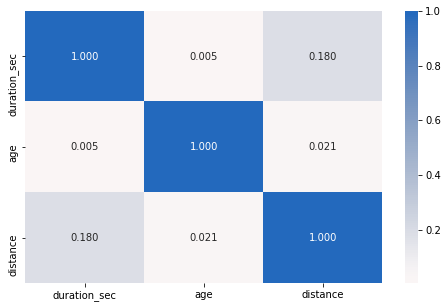

```python
#Pairwise relationships among the numeric variables
plt.figure(figsize = [8,5])
sb.heatmap(ford[numeric_columns].corr(), annot= True, fmt='.3f', cmap= 'vlag_r', center = 0)
plt.show()
```

#### Starting with the next section of figuring out the relationship of two variables. I started with the heat map to figure out the correlation between the numeric variables. According to the plot, there is no significant correlation among them despite the low correlation between distance and duration which 18%.

#### I thought that there could be a correlation among them where the distance and duration shall increase with age increasing and similarly between distance and duration.

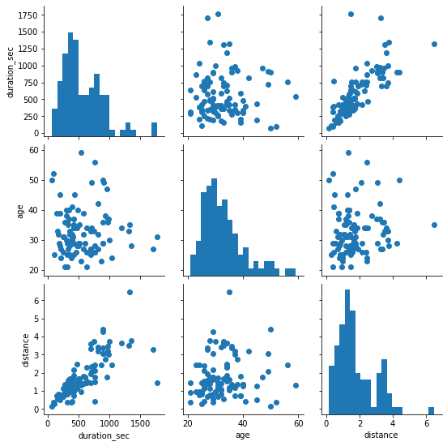

```python
# plot matrix: sample 500 diamondstrips so that plots are clearer
samples = np.random.choice(ford.shape[0], 100, replace = False)
ford_samp = ford.iloc[samples]
g = sb.PairGrid(data = ford_samp, vars = numeric_columns)
g = g.map_diag(plt.hist, bins = 20)
g.map_offdiag(plt.scatter);
```

#### I have run a small sample to be able to detect the trend if any clearly, however, based on the plot matrix, there is no correlation between the age with the duration and distance where the data shows either scattered points or change over the x axis. On the other hand, the distance shows a slight positive correlation with the duration where there is a gradual increasing trend as shown across the charts.

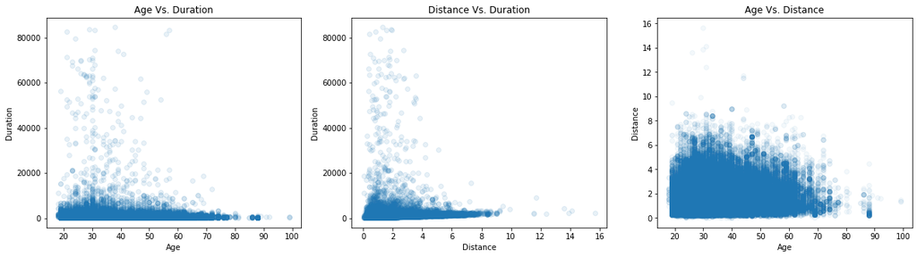

```python
plt.figure(figsize=[20,5])

plt.subplot(1,3,1)
plt.scatter(data=ford, x='age', y='duration_sec', alpha = 1/10)
plt.xlabel('Age')
plt.ylabel('Duration')
plt.title('Age Vs. Duration')

plt.subplot(1,3,2)
plt.scatter(data=ford, x='distance', y='duration_sec', alpha = 1/10)
plt.xlabel('Distance')
plt.ylabel('Duration')
plt.title('Distance Vs. Duration')

plt.subplot(1,3,3)
plt.scatter(data=ford, x='age', y='distance', alpha = 1/20)
plt.xlabel('Age')
plt.ylabel('Distance')
plt.title('Age Vs. Distance');
```

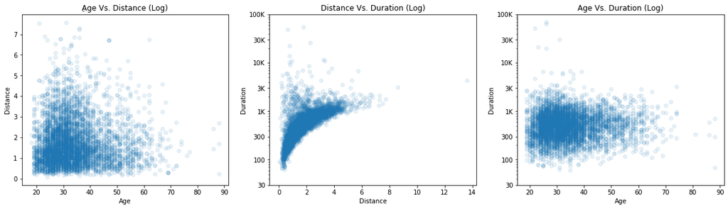

```python
plt.figure(figsize=[20,5])

plt.subplot(1,3,1)
samples = np.random.choice(ford.shape[0], 5000, replace = False)
ford_samp = ford.iloc[samples]
plt.scatter(data=ford_samp, x='age', y='distance', alpha = 1/10)
plt.xlabel('Age')
plt.ylabel('Distance')
plt.title('ِAge Vs. Distance (Log)')

plt.subplot(1,3,2)
samples = np.random.choice(ford.shape[0], 5000, replace = False)
ford_samp = ford.iloc[samples]
plt.scatter(data=ford_samp, x='distance', y='duration_sec', alpha = 1/10)
plt.xlabel('Distance')
plt.yscale('log')
plt.ylabel('Duration')
plt.yticks([30, 100, 300, 1000, 3000, 10000, 30000, 100000], [30, 100, 300, '1K', '3K', '10K', '30K', '100K'])
plt.title('Distance Vs. Duration (Log)')

plt.subplot(1,3,3)
samples = np.random.choice(ford.shape[0], 5000, replace = False)
ford_samp = ford.iloc[samples]
plt.scatter(data=ford_samp, x='age', y='duration_sec', alpha = 1/10)
plt.yscale('log')
plt.xlabel('Age')
plt.ylabel('Duration')
plt.yticks([30, 100, 300, 1000, 3000, 10000, 30000, 100000], [30, 100, 300, '1K', '3K', '10K', '30K', '100K'])
plt.title('Age Vs. Duration (Log)');
```

#### As a trial to figure a trend among the numeric variables by plotting them against each other using the log transform. So, it demonstartes a clearer positive correlation between the distance and duration as per the former graphs.

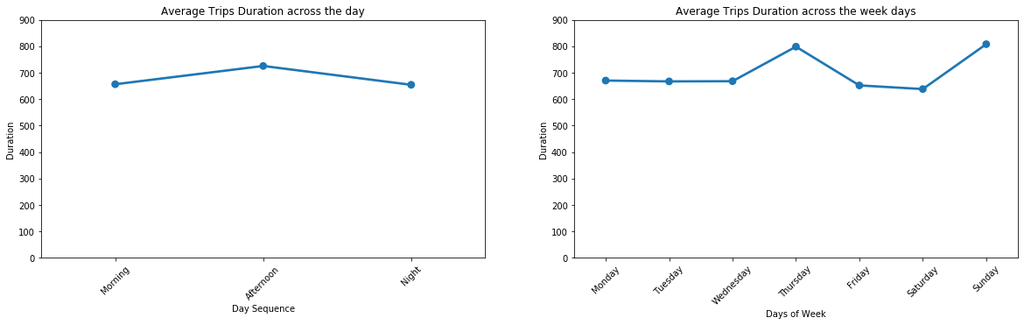

```python
plt.figure(figsize=[20,5])

plt.subplot(1,2,1)
sb.pointplot(data=ford, x='daysequence', y='duration_sec', errwidth=0)
plt.ylim(0, 900)
plt.xticks(rotation= 45)
plt.xlabel('Day Sequence')
plt.ylabel('Duration')
plt.title('Average Trips Duration across the day')

plt.subplot(1,2,2)
sb.pointplot(data=ford, x='dayofweek', y='duration_sec', errwidth=0)
plt.ylim(0, 900)
plt.xticks(rotation= 45)
plt.xlabel('Days of Week')
plt.ylabel('Duration')
plt.title('Average Trips Duration across the week days');
```

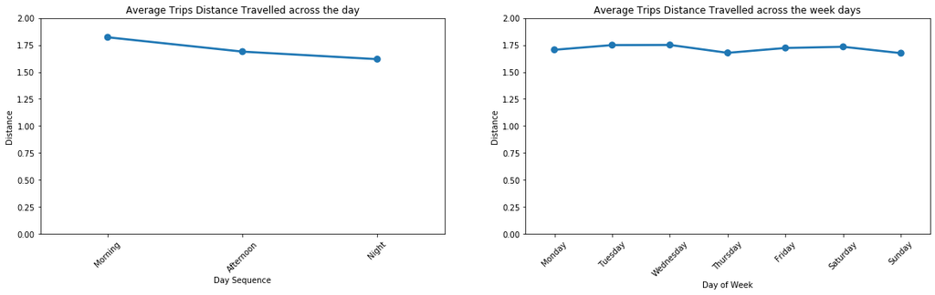

```python
plt.figure(figsize=[20,5])

plt.subplot(1,2,1)
sb.pointplot(data=ford, x='daysequence', y='distance')
plt.ylim(0,2)
plt.xticks(rotation= 45)
plt.xlabel('Day Sequence')
plt.ylabel('Distance')
plt.title('Average Trips Distance Travelled across the day')

plt.subplot(1,2,2)
sb.pointplot(data=ford, x='dayofweek', y='distance')
plt.ylim(0,2)
plt.xticks(rotation= 45)
plt.xlabel('Day of Week')
plt.ylabel('Distance')
plt.title('Average Trips Distance Travelled across the week days');
```

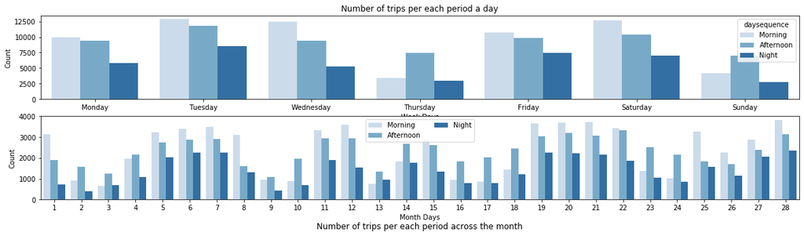

```python
plt.figure(figsize=[20,5])

plt.subplot(2,1,1)
sb.countplot(data= ford, x='dayofweek', hue='daysequence', palette="Blues")
plt.xlabel('Week Days')
plt.ylabel('Count')
plt.title('Number of trips per each period a day')

plt.subplot(2,1,2)
sb.countplot(data= ford, x='dayofmonth', hue='daysequence', palette="Blues")
plt.xlabel('Month Days')
plt.ylabel('Count')
plt.title('Number of trips per each period across the month', y=-0.4)
plt.legend(ncol = 2);
```

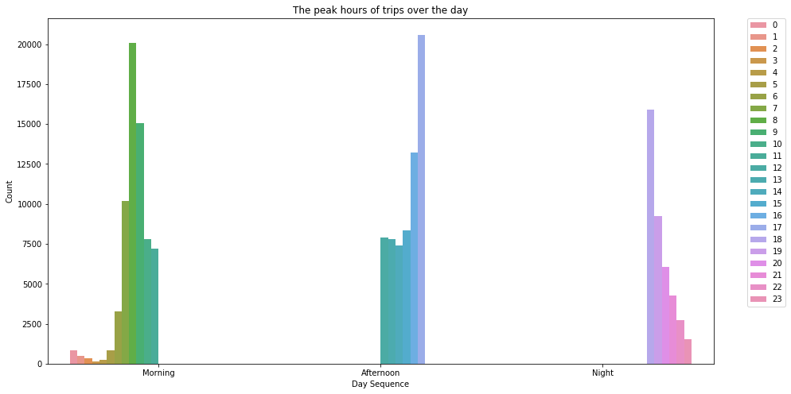

```python
plt.figure(figsize=[15,8])
sb.countplot(data=ford, x='daysequence', hue='starting_hour')
plt.legend(bbox_to_anchor=(1.05, 1), loc='upper left', borderaxespad=0.)
plt.xlabel('Day Sequence')
plt.ylabel('Count')
plt.title('The peak hours of trips over the day');
```

[output not shown]

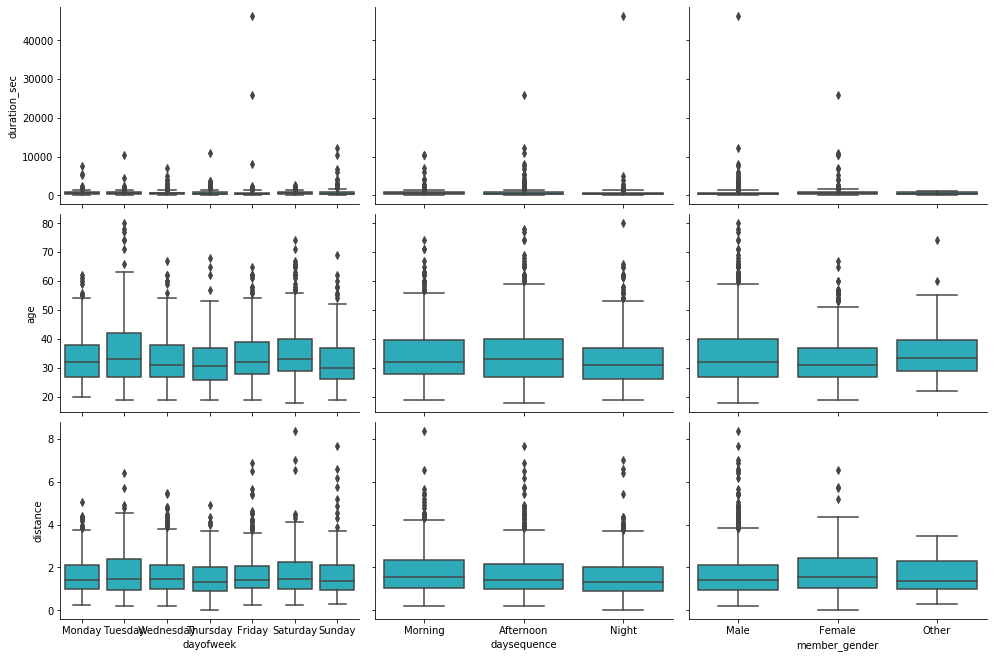

```python
# plot matrix of numeric features against categorical features using a sample of the data

samples = np.random.choice(ford.shape[0], 2000, replace = False)
ford_samp = ford.iloc[samples]

def boxgrid(x, y, **kwargs):
    """ Quick hack for creating box plots with seaborn's PairGrid. """
    default_color = sb.color_palette()[9]
    sb.boxplot(x, y, color = default_color)

plt.figure(figsize = [5, 5])
g = sb.PairGrid(data = ford_samp, y_vars = numeric_columns, x_vars = categorical_columns,
                size = 3, aspect = 1.5)
g.map(boxgrid)
plt.show();
```

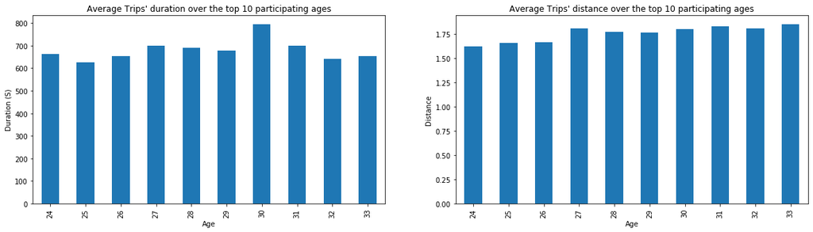

```python
top_ten_ages = ford['age'].value_counts().index[:10]
ford_ages = ford.loc[ford['age'].isin(top_ten_ages )]

plt.figure(figsize=[20, 5])
plt.subplot(1,2,1)
ford_ages.groupby('age')['duration_sec'].mean().plot(kind='bar')
plt.xlabel('Age')
plt.ylabel('Duration (S)')
plt.title('Average Trips\' duration over the top 10 participating ages')

plt.subplot(1,2,2)
ford_ages.groupby('age')[('distance')].mean().plot(kind='bar')
plt.xlabel('Age')
plt.ylabel('Distance')
plt.title('Average Trips\' distance over the top 10 participating ages')
```

#### Taking the average of distances travelled and durations taken over the trips for the top ten participating ages in the dataset reveals that they have nearly similar average distance travelled while age of 30 took more average time rather than the others. On the other hand, age of 33 is among least of time taken through the trips and higher distances travelled.

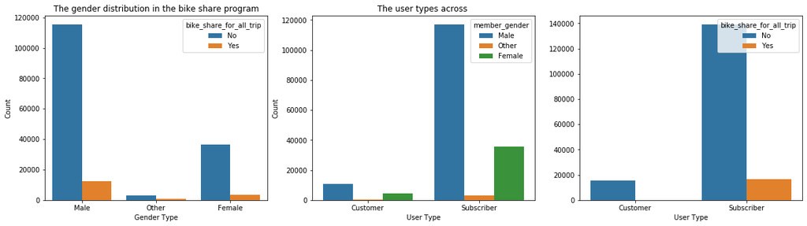

```python
plt.figure(figsize=[20,5])

plt.subplot(1,3,1)
sb.countplot(data= ford, x='member_gender', hue='bike_share_for_all_trip')
plt.xlabel('Gender Type')
plt.ylabel('Count')
plt.title('The gender distribution in the bike share program')

plt.subplot(1,3,2)
sb.countplot(data= ford, x='user_type', hue='member_gender')
plt.xlabel('User Type')
plt.ylabel('Count')
plt.title('The user types across ')

plt.subplot(1,3,3)
sb.countplot(data= ford, x='user_type', hue='bike_share_for_all_trip')
plt.xlabel('User Type')
plt.ylabel('')
plt.title('');
```

#### Looking at the data we have from another perspetive as we have dispalyed before the percentage of males to females, customers to subscribers and participants of bike share to non-participants. The graphs depict that the majority of men and women don't participate in the bike share program. Besides the majority of men and women are subscribers not customers. Finally, as per the definition of customer, they don't join the bike share program.

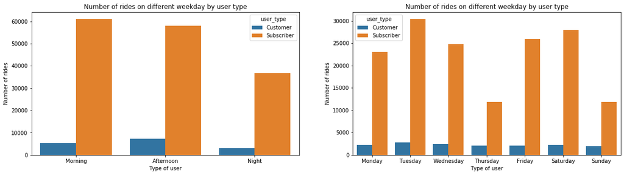

```python
plt.figure(figsize=[20,5])

plt.subplot(1,2,1)
sb.countplot(data = ford, x = 'daysequence', hue = 'user_type')
plt.xlabel('Type of user')
plt.ylabel('Number of rides')
plt.title('Number of rides on different weekday by user type');

plt.subplot(1,2,2)
sb.countplot(data = ford, x = 'dayofweek', hue = 'user_type')
plt.xlabel('Type of user')
plt.ylabel('Number of rides')
plt.title('Number of rides on different weekday by user type');
```

### Talk about some of the relationships you observed in this part of the investigation. How did the feature(s) of interest vary with other features in the dataset?

Additionally, the peak morning hours which have higher trips are in the range of 07:00 am to 09:00 am. In the afternoon, the peak hours are 04:00 pm and 05:00 pm. And the night has peak hours over 06:00 pm and 07:00 pm.

### Did you observe any interesting relationships between the other features (not the main feature(s) of interest)?

The majority of riders aren't part of the bike share program either males or females and the program participants are only subscribers. In addition, the maajority of participants either males or females are subscribers. In addition to some statistics can be observed from the box grid mentioned above like IQR over gender, week days and day period with distance, duration and age.

## Multivariate Exploration

[output not shown]

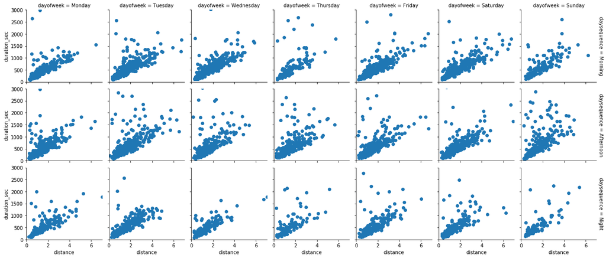

```python
#plotting the distance vs duration relation over day period of each week day
samples = np.random.choice(ford.shape[0], 5000, replace = False)
ford_samp = ford.iloc[samples]

g = sb.FacetGrid(data = ford_samp, col = 'dayofweek', row = 'daysequence', size = 2.5, margin_titles = True)
g.map(plt.scatter, 'distance', 'duration_sec')
plt.xlim(0, 7)
plt.ylim(0, 3000);
```

#### Looking at the relationship of interest between the distance and duration through an up-close view over two aspects "day of the week" and "day period" which ensures the positive correlation over the week days across the three day periods by using a random sample of the data.

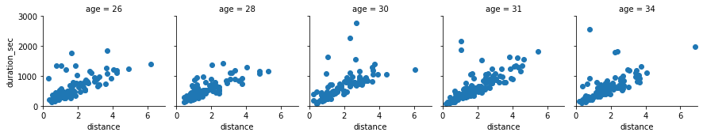

```python
#plotting the distance vs duration relation over the top 5 participating ages
samples = np.random.choice(ford.shape[0], 2000, replace = False)
ford_samp = ford.iloc[samples]

top_ten_ages = ford_samp['age'].value_counts().index[:5]
ford_ages = ford_samp.loc[ford['age'].isin(top_ten_ages )]

g = sb.FacetGrid(data = ford_ages, col = 'age', size = 2.5, margin_titles = True)
g.map(plt.scatter, 'distance', 'duration_sec')
plt.xlim(0, 7)
plt.ylim(0, 3000);
```

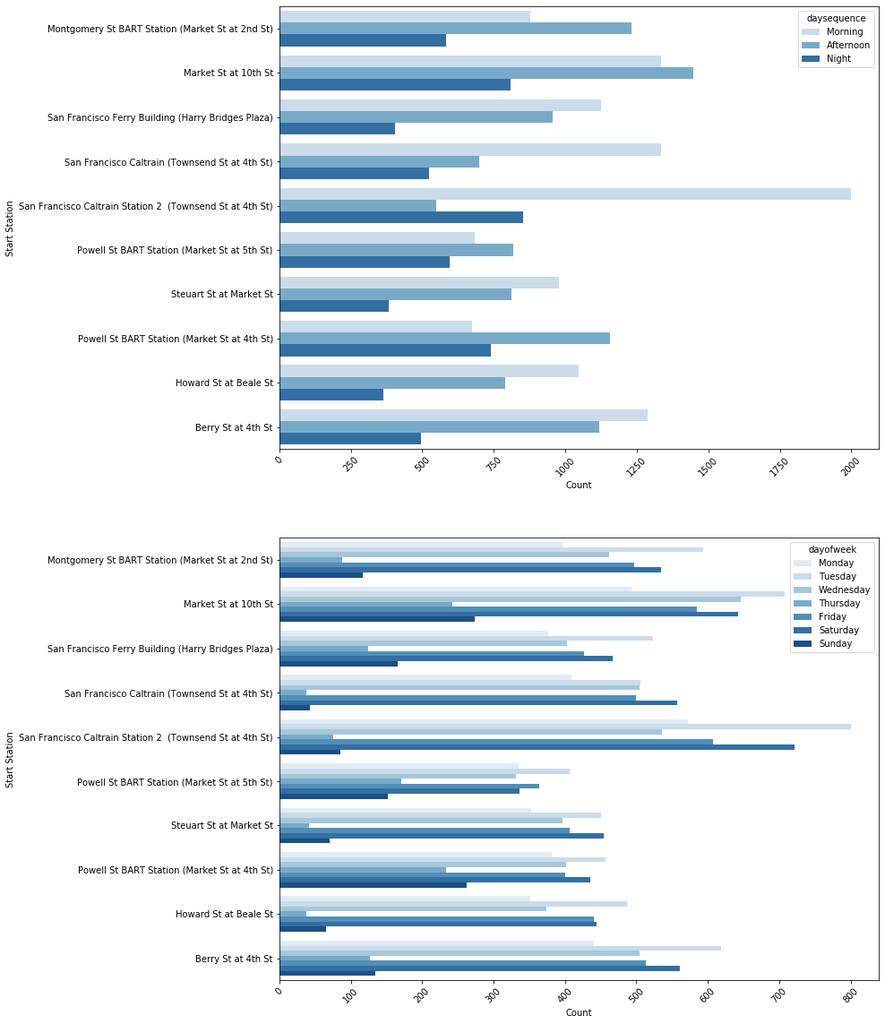

```python
#Demonstrating the number of trips per day over the top ten stations
top_ten_starts = ford['start_station_name'].value_counts().index[:10]
ford_stations = ford.loc[ford['start_station_name'].isin(top_ten_starts )]

plt.figure(figsize=[12,20])

plt.subplot(2,1,1)
sb.countplot(data=ford_stations, y='start_station_name', hue= 'daysequence',palette='Blues')
plt.xticks(rotation=45)
plt.xlabel('Count')
plt.ylabel('Start Station')

plt.subplot(2,1,2)
sb.countplot(data=ford_stations, y='start_station_name', hue= 'dayofweek',palette='Blues')
plt.xticks(rotation=45)
plt.xlabel('Count')
plt.ylabel('Start Station');
```

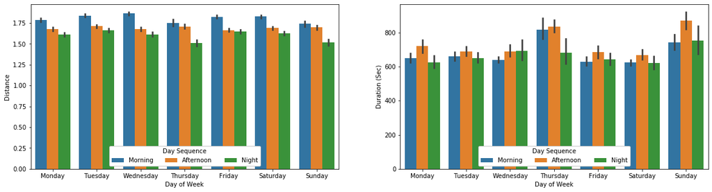

```python
#plotting the week periods across the week days in terms of distance and duration
plt.figure(figsize=[20,5])

plt.subplot(1,2,1)
sb.barplot(data = ford, x = 'dayofweek', y = 'distance', hue = 'daysequence')
plt.legend(loc = 8, ncol = 3, framealpha = 1, title = 'Day Sequence')
plt.xlabel('Day of Week')
plt.ylabel('Distance')


plt.subplot(1,2,2)
sb.barplot(data = ford, x = 'dayofweek', y = 'duration_sec', hue = 'daysequence')
plt.legend(loc = 8, ncol = 3, framealpha = 1, title = 'Day Sequence')
plt.xlabel('Day of Week')
plt.ylabel('Duration (Sec)');
```

#### This graph depicts the average distance travelled and time has taken over the weekdays across the day periods. The left graphs showcase that the morning of all the weekdays still witness higher distance traveled. While the duration in terms of the weekdays and the day periods are longer on average in the afternoon over most of the weekdays.

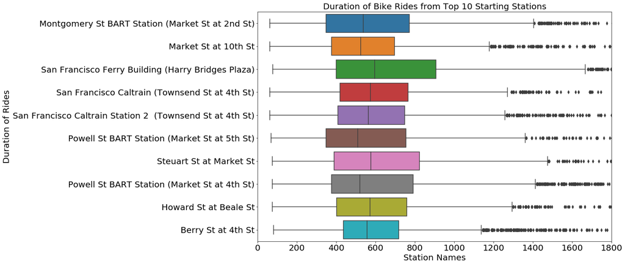

```python
top_ten_starts = ford['start_station_name'].value_counts().index[:10]
ford_stations = ford.loc[ford['start_station_name'].isin(top_ten_starts )]

plt.figure(figsize=[15,10])
sb.boxplot(data = ford_stations,  x= 'duration_sec', y = 'start_station_name')
plt.xlim(0, 1800)
plt.yticks(fontsize=20)
plt.xticks(fontsize=20)
plt.title('Duration of Bike Rides from Top 10 Starting Stations', fontsize=20)
plt.xlabel('Station Names', fontsize=20)
plt.ylabel('Duration of Rides', fontsize=20);
```

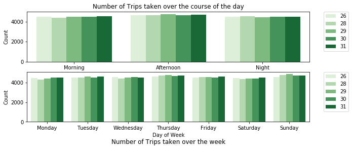

```python
#plotting the number of trips taken across the day and week days over the top 5 participating ages
top_ten_ages = ford['age'].value_counts().index[:5]
ford_ages = ford.loc[ford['age'].isin(top_ten_ages )]


plt.figure(figsize =[10,4])

plt.subplot(2,1,1)
sb.barplot(data = ford_ages, x = 'daysequence', y = 'bike_id',
             hue = 'age', palette = 'Greens', ci = None);
plt.legend(bbox_to_anchor=(1.05, 1), loc='upper left', borderaxespad=0.)
plt.xlabel('Day Sequence')
plt.ylabel('Count')
plt.title('Number of Trips taken over the course of the day')

plt.subplot(2,1,2)
sb.barplot(data = ford_ages, x = 'dayofweek', y = 'bike_id',
             hue = 'age', palette = 'Greens', ci = None);
plt.legend(bbox_to_anchor=(1.05, 1), loc='upper left', borderaxespad=0.)
plt.xlabel('Day of Week')
plt.ylabel('Count')
plt.title('Number of Trips taken over the week', y=-0.5);
```

### Talk about some of the relationships you observed in this part of the investigation. Were there features that strengthened each other in terms of looking at your feature(s) of interest?

In addition, a look has been given to the top ten starting stations in terms of number of trips = either over the day course or the day period which clarified which days and periods these stations used as starting ones. In addition to the range of time taken for the trips from nearly 400 to less 1000 seconds.

### Were there any interesting or surprising interactions between features?

The interaction between the age and both of duration and distance over the whole dataset. The number of subscribers and males in the dataset. The outliers of duration specifically. The number of trips across the top ten stations which outweigh that these are main stations. A more data related to different months would be so interesting to figure out all of these points over a few months.